# CWRU DSCI353-353M-453: Class 03a Predictive Analytics

Profs: R. H. French, L. S. Bruckman, P. Leu, K. Davis, S. Cirlos

TAs: W. Oltjen, K. Hernandez, M. Li, M. Li, D. Colvin

31 January, 2023

#### Class Readings, Assignments, Syllabus Topics

##### Textbooks

- Introduction to R and Data Science
  - For R, Coding, Inferential Statistics
    - Peng: R Programming for Data Science
    - Peng: Exploratory Data Analysis with R

Textbooks for this class

- OIS = Diez, Barr, Çetinkaya-Runde: Open Intro Stat v4
- R4DS = Wickham, Grolemund: R for Data Science

Textbooks for DSCI353/353M/453, And in your Repo now

- ISLR2 = James, Witten, Hastie, Tibshirani: Intro to Statistical Learning with R, 2nd Ed.
- ESL = Trevor Hastie, Tibshirani, Friedman: Elements of Statistical Learning
- DLwR = Chollet, Allaire: Deep Learning with R, 2nd Ed.

Magazine Articles about Deep Learning

- DL1 to DL6 are “Deep Learning” articles in 3-readings/2-articles/

#### Syllabus

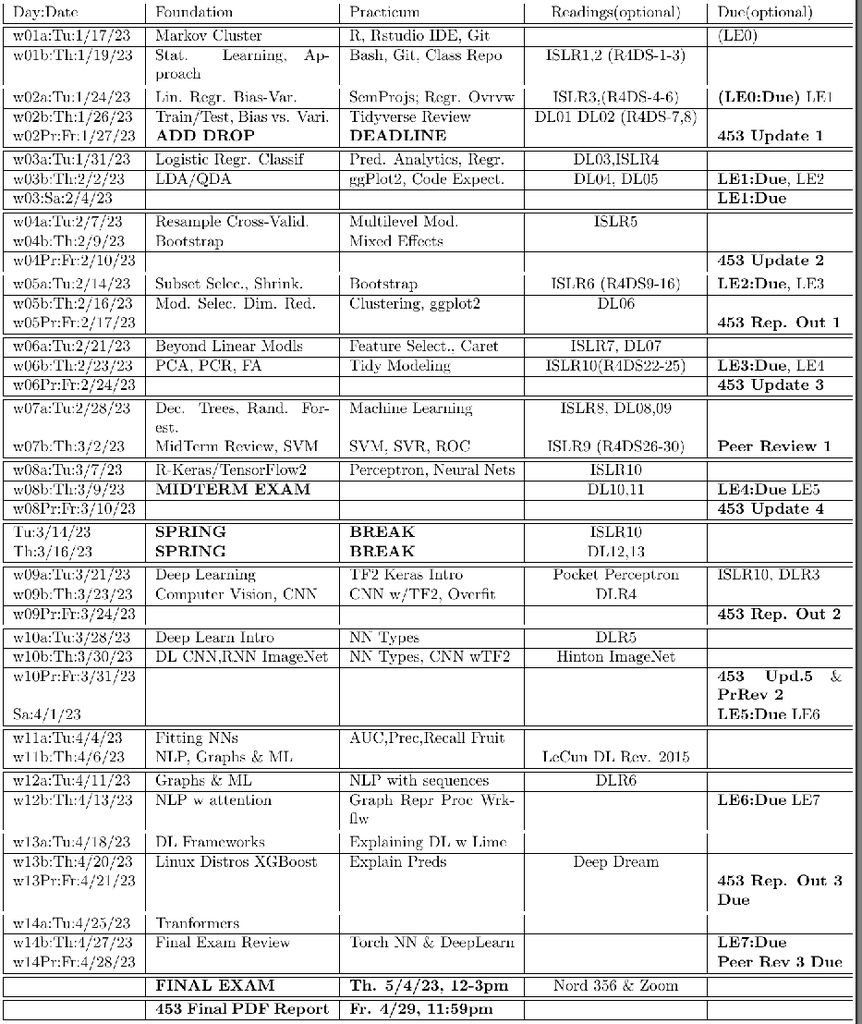

Modeling, Prediction and Machine Learning Syllabus

##### Tidyverse Cheatsheets, Functions and Reading Your Code

- Look at the Tidyverse Cheatsheet
  - **Tidyverse For Beginners Cheatsheet**
    - In the Git/20s-dsci353-353m-453-prof/3-readings/3-CheatSheets/ folder
  - **Data Wrangling with dplyr and tidyr Cheatsheet**

  Tidyverse Functions & Conventions
  - The pipe operator `%>%`
  - Use `dplyr::filter()` to subset data row-wise.
  - Use `dplyr::arrange()` to sort the observations in a data frame
  - Use `dplyr::mutate()` to update or create new columns of a data frame
  - Use `dplyr::summarize()` to turn many observations into a single data point
  - Use `dplyr::arrange()` to change the ordering of the rows of a data frame
  - Use `dplyr::select()` to choose variables from a tibble,
    - keeps only variables you mention
  - Use `dplyr::rename()` keeps all the variables and renames variables
    - rename(iris, petal_length = Petal.Length)
  - These can be combined using `dplyr::group_by()`
    - which lets you perform operations “by group”.
  - The `%in%` matches conditions provided by a vector using the c() function
  - The **forcats** package has tidyverse functions
    - for factors (categorical variables)
  - The **readr** package has tidyverse functions
    - to read_…, melt_… col_…, parse_… data and objects

Reading Your Code: Whenever you see

- The assignment operator `<-`, think **“gets”**
- The pipe operator, `%>%`, think **“then”**

#### What is Statistical (and Machine) Learning

- We will go far beyond classical inferential statistical methods,
  - such as linear regression.

As computing power has increased over the last 20 years

- many new, highly computational, regression, or “Statistical Learning”,
- methods have been developed.

In particular the last decade has seen a significant expansion

- of the number of possible approaches.

Here we will provide a very applied overview to such modern non-linear methods as

- Generalized Additive Models,
- Decision (or Regression) Trees,
- Boosting,
- Bagging and
- Support Vector Machines

As well as more classical linear approaches such as

- Logistic Regression,
- Linear Discriminant Analysis,
- K-Means Clustering and Nearest Neighbors.

At the end of this course you should have

- a basic understanding of how all of these methods work
- and be able to apply them in real data analyses.

With the explosion of “Big Data” problems,

- statistical learning has become a very hot field in many areas.

People with statistical learning skills are in high demand!

To this end, approximately one third of the class time

- is dedicated to in lab exercises
- where the students will work through
- the latest methods we have covered,
- on their Open Data Science VDI.

These labs will ensure that every student

- has a full understanding of the
- practical and theoretical, aspects of each method.

#### Supervised and Unsupervised Learning

- Two broad families of algorithms will be covered:
  - Unsupervised learning algorithms
  - Supervised learning algorithms

##### Unsupervised learning

- In unsupervised learning,
  - the algorithm will seek to find the structure that organizes unlabeled data.

##### Supervised learning

- In supervised learning,
  - we know the class or the level of some observations of a given target attribute.

#### Classification and Regresssion Problems

- There are basically two types of problems that predictive modeling deals with:
  - Classification problems
  - Regression problems

##### Classification

- In some cases,
  - we want to predict which group an observation is part of.

Here, we are dealing with a quality of the observation.

##### Regression

- In other cases,
  - we want to predict an observation’s level on an attribute.

Here, we are dealing with a quantity, and this is a regression problem.

#### The critical role of domain knowledge

- in modeling and prediction

Domain knowledge informs and is informed by data understanding.

- The understanding of the data
  - then informs how the data has to be prepared.

The next step is data modeling,

- which can also lead to further data preparation.

Data models have to be evaluated,

- and this evaluation can be informed by field knowledge,
  - which is also updated through the data mining process.

Finally,

- if the evaluation is satisfactory,
  - the models are deployed for prediction.

#### Caveat: For Predictive Analytics

- Of course, predictions are not always accurate,
  - and some have written about the caveats of data science.

What do you think about the relationship between

- the attributes titled Predictor and Outcome on the following plot?

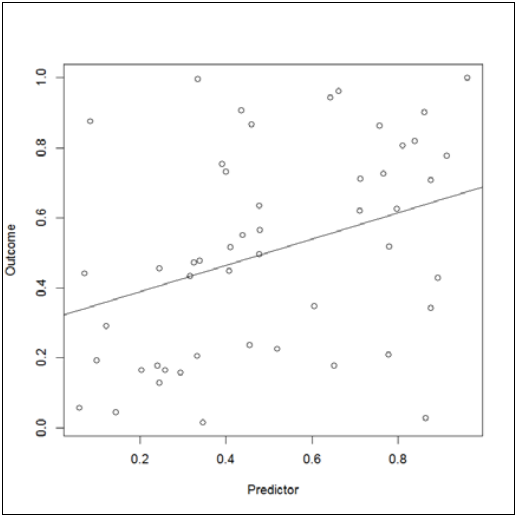

Relationship between Predictor & Outcome

It seems like there is a relationship between the two.

- For the statistically inclined,
  - I tested its significance:
    - r = 0.4195, p = .0024.
- The value p is the probability of obtaining a relationship of this strength or stronger
  - if there is actually no relationship between the attributes.
- ( This is the p-value of hypothesis testing, if p<0.05
  - typically we assert we can reject the null hypothesis)
- We could conclude that the relationship between these variables
  - in the population they come from is quite reliable,
  - **right?**

##### No: Lets think about this

- Believe it or not,
  - the population these observations come from
    - is that of randomly generated numbers.
  - We generated a data frame of 50 columns
    - of 50 randomly generated numbers.
  - We then examined all the correlations (manually)
    - and generated a scatterplot of the two attributes
    - with the largest correlation we found.

##### The code is provided here,

- We’ll use runif()
  - help(runif)
    - The Uniform Distribution
    - Description

These functions provide information about the uniform distribution

- on the interval from min to max.
  - dunif gives the density,
  - punif gives the distribution function
  - qunif gives the quantile function and
  - runif generates random deviates.

```r
set.seed(1)
DF <- data.frame(matrix(nrow = 50, ncol = 50))
for (i in 1:50)
  DF[, i] <- runif(50)
plot(DF[[2]], DF[[16]], xlab = "Predictor", ylab = "Outcome")
abline(lm(DF[[2]] ~ DF[[16]]))
cor.test(DF[[2]], DF[[16]])
```

In case you want to check it yourself

- line 1 sets the seed so that you find the same results as we did,
- line 2 generates to the data frame,
- line 3 fills it with random numbers, column by column,
- line 4 generates the scatterplot,
- line 5 fits the regression line, and
- line 6 tests the significance of the correlation:

Normally we reject the null with a p-value of <0.05

- i.e. we’ll be wrong 5% of the time
  - in a set of 20 trials

Here we did 50 trials

##### [Bonferroni Correction](https://en.wikipedia.org/wiki/Bonferroni_correction) for multiple comparisons

- How could this relationship happen given that the odds were 2.4 in 1000 ?
  - Well, think of it;
    - we correlated all 50 attributes 2 x 2,
    - which resulted in 2,450 tests
    - (not considering the correlation of each attribute with itself).
  - Such spurious correlation was quite expectable.

The usual p-value threshold below which

- we consider a relationship significant is p = 0.05.

This means that we expect to be wrong once in 20 times.

- You would be right to suspect that there are other significant correlations
  - in the generated data frame (there should be approximately 125 of them in total).
- This is the reason why we should always correct the number of tests.
- In our example,
  - as we performed 2,450 tests,
  - our threshold for significance
  - should be 0.0000204 (0.05 / 2450).
- This is called the Bonferroni correction.

#### Overfitting: The need for Trainging and Testing Datasets

- Spurious correlations are always a possibility in data analysis
  - and this should be kept in mind at all times.

A related concept is that of overfitting.

- Overfitting happens, for instance,
  - when a weak classifier bases its prediction on the noise in data.
- We will discuss overfitting when discussing
  - Training datasets for fit a model to
  - Testing datasets for evaluating the goodness of fit
    - when using various types of cross-validation
  - And when evaluating $Predictive, Adjusted, R^2$

#### Citations

1. R Core Team. R: A Language and Environment for Statistical Computing. Vienna, Austria: R Foundation for Statistical Computing, 2014. http://www.R-project.org/.
2. G. James, D. Witten, T. Hastie, and R. Tibshirani, An Introduction to Statistical Learning: 2nd Ed., with Applications in R, 2nd ed. 2021 edition. New York: Springer, 2021.
3. Diez, David M., Christopher D. Barr, and Mine Çetinkaya-Rundel. OpenIntro Statistics: Third Edition. 3 edition. S.l.: OpenIntro, Inc., 2015.
4. Al Sharif, IOM 530 – Applied Modern Statistical Learning Methods, USC
5. Mayor, Eric. Learning Predictive Analytics with R. Packt Publishing - ebooks Account, 2015.